# Yuen’s t-test: Type I error across trim parameters and sample sizes

Carolin Kirsch

2026-07-18

```r
library(dplyr)
library(tidyverse)
```

```r
library(tidyr)
library(ggplot2)
library(ggtext)
library(flextable)
library(apa7)
library(ftExtra)
library(DescTools)

set_flextable_defaults(theme_fun = theme_apa,
                        font.family = "Times New Roman")
```

```r
source("functions.R")
```

```r
n_iterations <-  30000L
alpha <- 0.05
```

Estimate the empirical Type I error rate of Yuen’s t-test across four trimming parameters, c ∈ {0.1, 0.15, 0.2, 0.25}, and a wide range of sample sizes (up to n = 500 per group). Sample sizes are shared across all four trim parameters and chosen so that exactly half of the conditions yield a whole number for c*n (simultaneously for all four trims) and half do not, with the two variants always placed directly next to each other (n and n+1) and increasingly large steps between these pairs across the sample size range.

# functions

## data analysis: Yuen’s t-test

```r
get_p_yuen_sim <- function(n, trim) {
  data <- generate_data_ttest(n_control = n)
  YuenTTest(score ~ condition, data, alternative = "two.sided", trim = trim)$p.value
}
```

# simulation

## design: sample sizes shared across trim parameters

`c*n` is a whole number only if `n` is a multiple of the period `q` of `c` (e.g. q = 10 for c = 0.1, q = 4 for c = 0.25). Using `q = 20`, the least common multiple of the periods of all four trims (10, 20, 5, 4), makes `c*n` a whole number for **all four trims simultaneously** whenever `n` is a multiple of 20 (`cn_integer = TRUE`) — and not a whole number for any of them at `n` + 1 (`cn_integer = FALSE`, `n` - 1 at the upper boundary n = 500). This gives one shared n-grid for all trims, with sample sizes directly comparable across trim parameters. Anchor points are placed with increasing spacing from n = 20 to n = 500.

```r
trims <- c(0.10, 0.15, 0.20, 0.25)
q_shared <- 20L
n_max <- 500

anchors <- unique(round(exp(seq(log(20), log(n_max), length.out = 16))))
n_int <- unique(pmax(q_shared, round(anchors / q_shared) * q_shared))
n_int <- pmin(n_int, n_max)
n_noninc <- if_else(n_int == n_max, n_int - 1L, n_int + 1L)

n_design <- bind_rows(
  tibble(n = n_int, cn_integer = TRUE),
  tibble(n = n_noninc, cn_integer = FALSE)
) |>
  arrange(n)

n_design
```

```
## # A tibble: 24 × 2
##        n cn_integer
##    <dbl> <lgl>
##  1    20 TRUE
##  2    21 FALSE
##  3    40 TRUE
##  4    41 FALSE
##  5    60 TRUE
##  6    61 FALSE
##  7    80 TRUE
##  8    81 FALSE
##  9   120 TRUE
## 10   121 FALSE
## # ℹ 14 more rows
```

## simulation grid

```r
par_grid_yuen_trim <- expand_grid(
  n_design,
  trim = trims,
  iteration = 1:n_iterations
)
```

```r
sim_yuen_trim_file <- paste0("results/sim_yuen_trim_", n_iterations, "iterations.rds")

if (!file.exists(sim_yuen_trim_file)) {
  set.seed(9182)

  sim_yuen_trim <- par_grid_yuen_trim |>
    mutate(
      p_value = map2_dbl(n, trim, get_p_yuen_sim)
    )

  saveRDS(sim_yuen_trim, sim_yuen_trim_file)
} else {
  sim_yuen_trim <- readRDS(sim_yuen_trim_file)
}
```

# results

## summary: empirical Type I error by trim, n, and integer status

```r
sim_summary_yuen_trim_file <- paste0("results/sim_summary_yuen_trim_", n_iterations, "iterations.rds")

if (!file.exists(sim_summary_yuen_trim_file)) {
  sim_summary_yuen_trim <- sim_yuen_trim |>
    group_by(trim, n, cn_integer) |>
    summarize(
      empirical_detection_rate = mean(p_value < alpha),
      empirical_detection_rate_mcse = sqrt(empirical_detection_rate * (1 - empirical_detection_rate) / n()),
      .groups = "drop"
    ) |>
    mutate(
      empirical_detection_rate_95CI_low = empirical_detection_rate - empirical_detection_rate_mcse * 1.96,
      empirical_detection_rate_95CI_upp = empirical_detection_rate + empirical_detection_rate_mcse * 1.96,
    )

  saveRDS(sim_summary_yuen_trim, sim_summary_yuen_trim_file)
} else {
  sim_summary_yuen_trim <- readRDS(sim_summary_yuen_trim_file)
}

sim_summary_yuen_trim
```

```
## # A tibble: 96 × 7
##     trim     n cn_integer empirical_detection_rate empirical_detection_rate_mcse
##    <dbl> <dbl> <lgl>                         <dbl>                         <dbl>
##  1   0.1    20 TRUE                         0.0481                       0.00123
##  2   0.1    21 FALSE                        0.0497                       0.00125
##  3   0.1    40 TRUE                         0.0499                       0.00126
##  4   0.1    41 FALSE                        0.0515                       0.00128
##  5   0.1    60 TRUE                         0.0504                       0.00126
##  6   0.1    61 FALSE                        0.0519                       0.00128
##  7   0.1    80 TRUE                         0.0496                       0.00125
##  8   0.1    81 FALSE                        0.0479                       0.00123
##  9   0.1   120 TRUE                         0.0502                       0.00126
## 10   0.1   121 FALSE                        0.0501                       0.00126
## # ℹ 86 more rows
## # ℹ 2 more variables: empirical_detection_rate_95CI_low <dbl>,
## #   empirical_detection_rate_95CI_upp <dbl>
```

```r
sim_summary_yuen_trim |>
  mutate(`trim c` = as.character(trim),
         `n per condition` = as.character(n),
         `c x n integer` = if_else(cn_integer, "yes", "no")) |>
  mutate(across(where(is.numeric), \(x) scales::number(x, accuracy = 0.001))) |>
  mutate(edr_string = paste0(empirical_detection_rate,
                             " (",
                             empirical_detection_rate_mcse,
                             ")")) |>
  select(`trim c`,
         `n per condition`,
         `c x n integer`,
         `empirical FPR (±1 MCSE)` = edr_string) |>
  apa_flextable(no_format_columns = `n per condition`) |>
  align(j = 1:3, align = "center") |>
  add_footer_lines(values = as_paragraph(as_i("Note. "), "Values in parentheses are ±1 Monte Carlo Standard Error."))
```

| trim c | n per condition | c x n integer | empirical FPR (±1 MCSE) |
| --- | --- | --- | --- |
| 0.1 | 20 | yes | 0.048 (0.001) |
| 0.1 | 21 | no | 0.050 (0.001) |
| 0.1 | 40 | yes | 0.050 (0.001) |
| 0.1 | 41 | no | 0.051 (0.001) |
| 0.1 | 60 | yes | 0.050 (0.001) |
| 0.1 | 61 | no | 0.052 (0.001) |
| 0.1 | 80 | yes | 0.050 (0.001) |
| 0.1 | 81 | no | 0.048 (0.001) |
| 0.1 | 120 | yes | 0.050 (0.001) |
| 0.1 | 121 | no | 0.050 (0.001) |
| 0.1 | 140 | yes | 0.051 (0.001) |
| 0.1 | 141 | no | 0.049 (0.001) |
| 0.1 | 180 | yes | 0.048 (0.001) |
| 0.1 | 181 | no | 0.051 (0.001) |
| 0.1 | 220 | yes | 0.051 (0.001) |
| 0.1 | 221 | no | 0.050 (0.001) |
| 0.1 | 260 | yes | 0.050 (0.001) |
| 0.1 | 261 | no | 0.049 (0.001) |
| 0.1 | 320 | yes | 0.049 (0.001) |
| 0.1 | 321 | no | 0.051 (0.001) |
| 0.1 | 400 | yes | 0.049 (0.001) |
| 0.1 | 401 | no | 0.053 (0.001) |
| 0.1 | 499 | no | 0.049 (0.001) |
| 0.1 | 500 | yes | 0.049 (0.001) |
| 0.15 | 20 | yes | 0.045 (0.001) |
| 0.15 | 21 | no | 0.049 (0.001) |
| 0.15 | 40 | yes | 0.048 (0.001) |
| 0.15 | 41 | no | 0.051 (0.001) |
| 0.15 | 60 | yes | 0.049 (0.001) |
| 0.15 | 61 | no | 0.051 (0.001) |

[output cut: 66 more lines]

Note. Values in parentheses are ±1 Monte Carlo Standard Error.

## plot

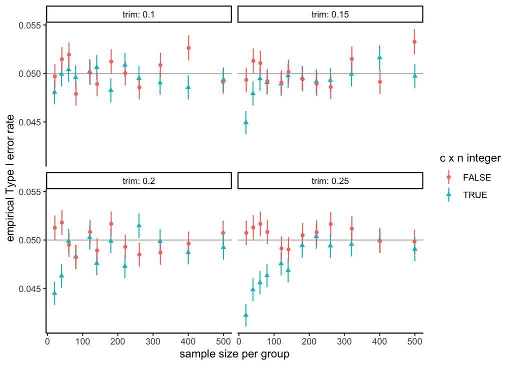

```r
ggplot(sim_summary_yuen_trim,
       aes(x = n,
           y = empirical_detection_rate,
           color = cn_integer,
           shape = cn_integer)) +
  geom_hline(yintercept = alpha, colour = "grey") +
  geom_linerange(aes(ymin = empirical_detection_rate - empirical_detection_rate_mcse,
                      ymax = empirical_detection_rate + empirical_detection_rate_mcse)) +
  geom_point() +
  facet_wrap(~ trim, labeller = label_both) +
  labs(
    x = "sample size per group",
    y = "empirical Type I error rate",
    color = "c x n integer",
    shape = "c x n integer") +
  theme(text = element_text(size = 14)) +
  theme_classic()
```